# **PART B: Customer Segmentation with Unsupervised Learning**

**Name:** Ng Yu Hang  
**Admin Number:** [student-id]  
**Class:** DAAA/FT/1B/07

## **Project Objective**

> **Background:**  
> We collected information from **200 customers**, including their **Gender**, **Age**, **Income**, and **How Much They Spend**.  
> The goal is to group customers into **clusters** to better understand their needs and create targeted strategies.

> **Dataset:**  
> You are going to use the dataset: **CA2-Customer-Data.csv**, which contains:
> - **Gender**
> - **Age**
> - **Income (k$)**
> - **How Much They Spend**

### **Tasks:**

> **1. Clustering Task:**  
> Write the code to solve the clustering task. Use the **scikit-learn** library to build the model.  
> *Note: Do not use other autoML libraries.*

> **2. Jupyter Notebook Report:**  
> In the Jupyter notebook, write your report detailing your implementation, your experiments, and analysis.  
> Include your **Python code with comments**.

> **3. Hyperparameter Tuning:**  
> Test your clustering with different possible values of **k**.  
> Determine the best possible value of **k**, and show how you can determine that this is the best value.

> **4. Multiple Clustering Models:**  
> Use more than just one clustering algorithm (**e.g., K-Means, DBSCAN, Agglomerative Clustering, GMM**).  
> Compare their results and effectiveness.

> **5. Model Evaluation:**  
> Analyze the clusters and describe the characteristics of each customer group.  
> Identify **which group of customers needs more attention** and explain why.

> **6. Presentation Slides:**  
> Create a set of slides summarizing your Jupyter notebook report.
> - Explain the entire machine learning process you went through:
>   - **Data exploration, data cleaning, feature engineering, model building, model evaluation, and model improvement.**
> - Write your conclusions.
> - The slides should **not exceed 20 pages**.

# **Phases**

> The project is divided into the following 6 phases:
> 1. **Data Collection and Preprocessing**
> - The dataset is loaded and cleaned by handling missing values, duplicates, and outliers. Feature engineering is performed, and numerical features are standardized. Dimensionality reduction techniques such as PCA and t-SNE are applied for better visualization and clustering efficiency.
> 2. **Exploratory Data Analysis (EDA)**
> - EDA is conducted to uncover patterns, trends, and relationships within the data. Visualizations such as histograms, scatter plots, and heatmaps are used to analyze feature distributions and correlations. Insights from this phase guide feature selection for clustering.
> 3. **Implementing Multiple Clustering Models**
> - Four clustering models are implemented: **K-Means**, **Agglomerative**, **DBSCAN**, and **GMM**. The optimal number of clusters is determined using methods such as the Elbow Method, Silhouette Score, and Dendrogram analysis. Model performance is evaluated using clustering metrics.
> 4. **Clustering Model Comparison & Final Insights**
> - The performance of all clustering models is compared using key metrics such as **Silhouette Score**, **Davies-Bouldin Index**, and **Calinski-Harabasz Score**. Visual comparisons of cluster formations help identify the most suitable model for customer segmentation.
> 5. **Business Insights & Final Conclusions**
> - Customer segments are profiled based on cluster characteristics such as **age, income, spending patterns, and efficiency scores**. Key insights are derived to suggest targeted marketing strategies and customer engagement plans for each segment.
> 6. **Answering Business Questions with Visualizations**
> - Key business questions are addressed through visualizations that explain customer behavior across segments. Plots such as income vs. spending and age vs. spending are used to identify high-value customers, budget-conscious consumers, and potential growth segments.

# **Importing Necessary Libraries** ðŸ“š

Before diving into the analysis, we'll import the necessary libraries for **data manipulation**, **visualization**, **modeling**, and **evaluation**.

```python
# Data Manipulation and Numerical Operations
import pandas as pd
import numpy as np

# Visualization
import matplotlib.pyplot as plt
import seaborn as sns

# Warnings Management
import warnings
warnings.filterwarnings("ignore")

# Statistical Analysis
from scipy.stats.mstats import winsorize

# Machine Learning - Preprocessing and Dimensionality Reduction
from sklearn.preprocessing import StandardScaler
from sklearn.decomposition import PCA
from sklearn.manifold import TSNE

# Machine Learning - Clustering Models
from sklearn.cluster import KMeans, AgglomerativeClustering, DBSCAN
from sklearn.mixture import GaussianMixture

# Machine Learning - Clustering Metrics
from sklearn.metrics import (
    silhouette_score,
    davies_bouldin_score,
    calinski_harabasz_score
)

# Hierarchical Clustering Tools
import scipy.cluster.hierarchy as sch

# Nearest Neighbors for DBSCAN Epsilon Estimation
from sklearn.neighbors import NearestNeighbors
```

# **Phase 1: Data Collection and Preprocessing**

> In this phase, we'll cover the following key processes to ensure our dataset is clean, consistent, and ready for clustering models:

### **Data Loading and Initial Inspection**

- Loading the `CA2-Customer-Data.csv` file into a Pandas DataFrame.
- Inspecting the dataset using `.head()`, `.info()`, and `.describe()` to understand its structure and summary statistics.

### **Data Cleaning**

- **Handling Missing Values:** Checking for and addressing any missing values using appropriate imputation techniques.
- **Removing Duplicates:** Identifying and removing duplicate records to ensure data integrity.
- **Dropping Irrelevant Columns:** Excluding non-contributory features such as `CustomerID`.

### **Feature Engineering**

- **Categorical Encoding:** Converting `Gender` into numerical values (`Male â†’ 0`, `Female â†’ 1`).
- **Derived Features:** Creating new metrics such as **Spending Efficiency** (`Spending / Income`).

### **Outlier Detection and Treatment**

- **Detecting Outliers:** Using **Z-score** and **IQR methods** to identify extreme values.
- **Treating Outliers:** Applying **Winsorization** to cap outliers and maintain data consistency.

### **Feature Scaling**

- **Standardization:** Using `StandardScaler` to normalize numerical features, ensuring equal importance during clustering.

### **Dimensionality Reduction**

- **PCA (Principal Component Analysis):** Reducing feature dimensions while retaining variance for better model efficiency.
- **t-SNE (t-Distributed Stochastic Neighbor Embedding):** Visualizing potential clusters by mapping high-dimensional data to 2D.

> **Outcome:**  
> By the end of this phase, the dataset will be fully cleaned, enriched with new features, and standardized, ensuring it is ready for effective customer segmentation through clustering models.

```python
# Load the dataset
df = pd.read_csv("CA2-Customer-Data.csv")

# Display first few rows
print("First 5 rows of the dataset:")
print(df.head())

# Check dataset information
print("\nDataset Information:")
print(df.info())
```

```
First 5 rows of the dataset:
   CustomerID  Gender  Age  Income (k$)  How Much They Spend
0           1    Male   19           15                   39
1           2    Male   21           15                   81
2           3  Female   20           16                    6
3           4  Female   23           16                   77
4           5  Female   31           17                   40

Dataset Information:
<class 'pandas.core.frame.DataFrame'>
RangeIndex: 200 entries, 0 to 199
Data columns (total 5 columns):
 #   Column               Non-Null Count  Dtype
---  ------               --------------  -----
 0   CustomerID           200 non-null    int64
 1   Gender               200 non-null    object
 2   Age                  200 non-null    int64
 3   Income (k$)          200 non-null    int64
 4   How Much They Spend  200 non-null    int64
dtypes: int64(4), object(1)
memory usage: 7.9+ KB
None
```

### **Dataset Overview**

> This dataset contains **200 customer records** with **5 features**.

#### **Key Observations:**

- **No missing values** detected in any column.
- **Gender is categorical**, while other columns are numerical.
- **Income and spending data** are recorded in thousands of dollars.
- **Age distribution spans different age groups**, indicating diverse customer demographics.

```python
# Summary statistics
print("\nSummary Statistics:")
print(df.describe())

# Check for missing values
print("\nMissing values per column:")
print(df.isnull().sum())

# Check for duplicates
duplicate_count = df.duplicated().sum()
print(f"\nðŸ—‘ Duplicate Rows Found: {duplicate_count}")
```

```
Summary Statistics:
       CustomerID         Age  Income (k$)  How Much They Spend
count  200.000000  200.000000   200.000000           200.000000
mean   100.500000   38.850000    60.560000            50.200000
std     57.879185   13.969007    26.264721            25.823522
min      1.000000   18.000000    15.000000             1.000000
25%     50.750000   28.750000    41.500000            34.750000
50%    100.500000   36.000000    61.500000            50.000000
75%    150.250000   49.000000    78.000000            73.000000
max    200.000000   70.000000   137.000000            99.000000

Missing values per column:
CustomerID             0
Gender                 0
Age                    0
Income (k$)            0
How Much They Spend    0
dtype: int64

ðŸ—‘ Duplicate Rows Found: 0
```

### **Summary Statistics Analysis**

> Overview of key numerical features in the dataset.

#### **Key Insights:**

- **Age:** Ranges from **18 to 70 years**, with a median of **36 years**.
- **Income:** Ranges from **15k to 137k**, with a median of **61.5k**.
- **Spending:** Ranges from **1 to 99**, with a median of **50**.

#### **Data Quality Check:**

- **No missing values** in any column.
- **No duplicate records** found.
- Data types are appropriate for analysis.

# **Phase 1.2: Handling Missing Values, Duplicates & Data Cleaning**

### **Objective**

Now that we have inspected the dataset, we will:  
**Drop unnecessary columns** (CustomerID is not needed for clustering).  
**Handle categorical variables** (Convert Gender into numerical values).  
**Detect and remove outliers** to prevent skewed clustering.

### **Steps**

1. **Drop CustomerID Column**
   - CustomerID is a unique identifier and holds no meaningful value for clustering.
2. **Convert Categorical Features**
   - The `Gender` column will be **mapped to numerical values** (`Male â†’ 0`, `Female â†’ 1`).
3. **Outlier Detection & Treatment**
   - Outliers can distort clustering results.
   - We will use **Z-score and Interquartile Range (IQR) methods** to detect extreme values.
   - Any detected outliers will be reviewed before removal.

```
ðŸš¨ Outlier Count Per Feature:
Gender                 0
Age                    0
Income (k$)            2
How Much They Spend    0
dtype: int64
```

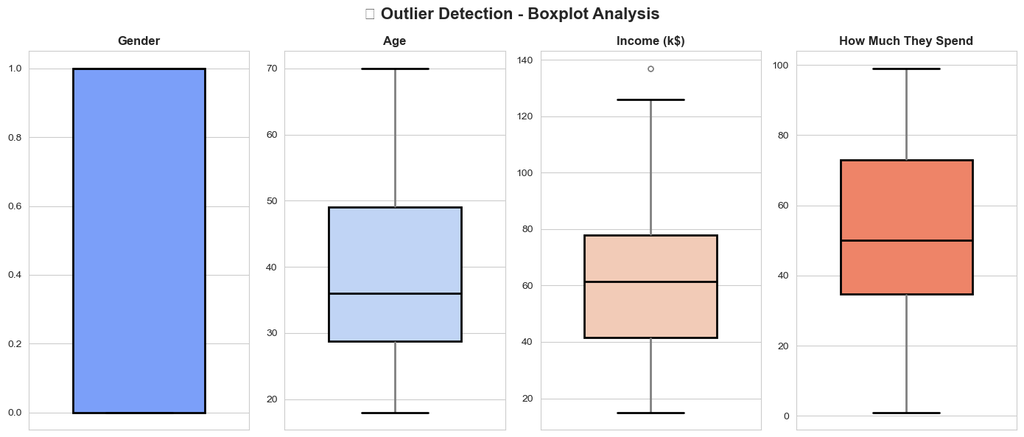

```python
# Drop unnecessary columns
df = df.drop(columns=["CustomerID"])

# Convert categorical feature "Gender" to numerical
df["Gender"] = df["Gender"].map({"Male": 0, "Female": 1})

# Function to detect outliers using Z-score
def detect_outliers_zscore(data, threshold=3):
    z_scores = np.abs((data - data.mean()) / data.std())
    return z_scores > threshold

# Function to detect outliers using IQR
def detect_outliers_iqr(data):
    Q1 = data.quantile(0.25)
    Q3 = data.quantile(0.75)
    IQR = Q3 - Q1
    return (data < (Q1 - 1.5 * IQR)) | (data > (Q3 + 1.5 * IQR))

# Apply both outlier detection methods
zscore_outliers = df.apply(detect_outliers_zscore)
iqr_outliers = df.apply(detect_outliers_iqr)

# Combine results
outlier_counts = (zscore_outliers | iqr_outliers).sum()

# Display number of detected outliers per column
print("Outlier Count Per Feature:")
print(outlier_counts)

# Set the style for better aesthetics
sns.set_style("whitegrid")

# Create a more visually appealing boxplot
plt.figure(figsize=(14, 6))
palette = sns.color_palette("coolwarm", len(df.columns))

for i, column in enumerate(df.columns):
    plt.subplot(1, 4, i + 1)

    # Enhanced boxplot with advanced styling
    sns.boxplot(
        y=df[column],
        color=palette[i],
        width=0.6,
        linewidth=2.5,
        fliersize=5,  # Adjust size of outlier points
        medianprops={"color": "black", "linewidth": 2},  # Styling median line
        whiskerprops={"linewidth": 2, "color": "gray"},  # Styling whiskers
        capprops={"linewidth": 2, "color": "black"},  # Styling caps
        boxprops={"facecolor": palette[i], "edgecolor": "black", "linewidth": 2},  # Styling box
    )

    plt.title(column, fontsize=12, fontweight="bold")
    plt.ylabel("")  # Remove y-axis label for a cleaner look

# Overall plot settings
plt.suptitle(" Outlier Detection - Boxplot Analysis", fontsize=16, fontweight="bold")
plt.tight_layout()
plt.show()
```

### **Boxplot Analysis for Outlier Detection**

> Overview of the distribution and spread of key numerical features.

#### **Key Insights:**

- **Gender:** Only two categories (Male = 0, Female = 1), no anomalies.
- **Age:** Even distribution from **18 to 70**, no significant outliers.
- **Income:** One outlier above **130k**, which may represent a high-net-worth individual.
- **Spending:** Broad range from **1 to 99**, with no apparent extreme outliers.

#### **Data Quality Check:**

- Outliers appear minimal, indicating the data is well-prepared.
- No need for further outlier removal.

# **Phase 1.3: Handling Outliers & Feature Engineering**

### **Objective**

Now that we have detected outliers using **Z-score and IQR methods**, we will:  
**Decide whether to remove or cap extreme values** based on business logic.  
**Create new derived features** to enhance clustering relevance.  
**Prepare data for scaling and transformation**.

### **Steps**

1. **Outlier Treatment**
   - Outliers in **Income** might indicate high-net-worth individuals, which could be valid.
   - Instead of removing, we **cap extreme values** using the **Winsorization technique**.
2. **Feature Engineering**
   - **Spending Efficiency Score** = `How Much They Spend / Income`
   - **Age-Income Ratio** = `Income / Age`
3. **Final Data Preparation**
   - Store the cleaned and feature-engineered dataset for further processing.

```python
# Winsorization: Capping extreme values
df["Income (k$)"] = winsorize(df["Income (k$)"], limits=[0.01, 0.01])  # Cap top & bottom 1%
df["How Much They Spend"] = winsorize(df["How Much They Spend"], limits=[0.01, 0.01])

# Feature Engineering - Creating new derived features
df["Spending Efficiency"] = df["How Much They Spend"] / df["Income (k$)"]
df["Age-Income Ratio"] = df["Income (k$)"] / df["Age"]

# Display dataset after processing
print("\n Updated Dataset After Feature Engineering:")
df.head()
```

```
 Updated Dataset After Feature Engineering:
```

|  | Gender | Age | Income (k$) | How Much They Spend | Spending Efficiency | Age-Income Ratio |
| --- | --- | --- | --- | --- | --- | --- |
| 0 | 0 | 19 | 16 | 39 | 2.437500 | 0.842105 |
| 1 | 0 | 21 | 16 | 81 | 5.062500 | 0.761905 |
| 2 | 1 | 20 | 16 | 6 | 0.375000 | 0.800000 |
| 3 | 1 | 23 | 16 | 77 | 4.812500 | 0.695652 |
| 4 | 1 | 31 | 17 | 40 | 2.352941 | 0.548387 |

# **Phase 1.4: Feature Scaling & Dimensionality Reduction**

### **Objective**

Now that our dataset is cleaned and feature-engineered, we need to:  
**Normalize numerical features to ensure uniform impact on clustering.**  
**Use PCA (Principal Component Analysis) for dimensionality reduction.**  
**Apply t-SNE for visualizing potential clusters.**

### **Steps**

```
PCA Reduced Dataset:
       PCA1      PCA2  Gender
0  2.127096 -0.779575       0
1  3.821184 -2.766737       0
2  0.879225  0.932429       1
3  3.721171 -2.455149       1
4  2.332363 -0.138528       1

t-SNE Transformed Dataset:
      tSNE1     tSNE2  Gender
0  1.515202 -7.657561       0
1  5.101877 -9.184182       0
2 -2.617802 -9.565855       1
3  4.862892 -9.036869       1
4  0.918088 -7.482295       1
```

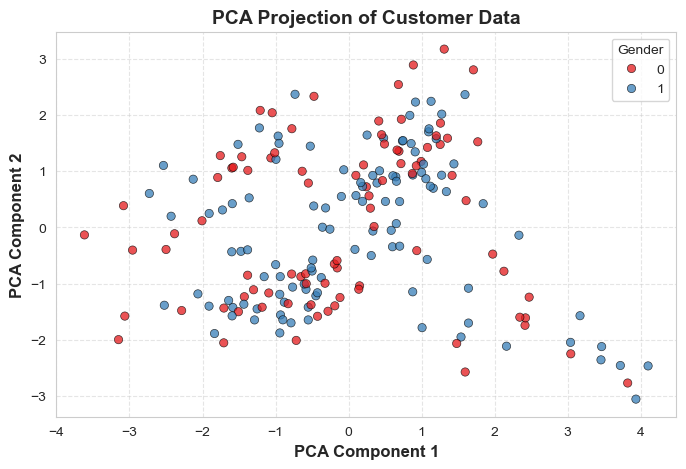

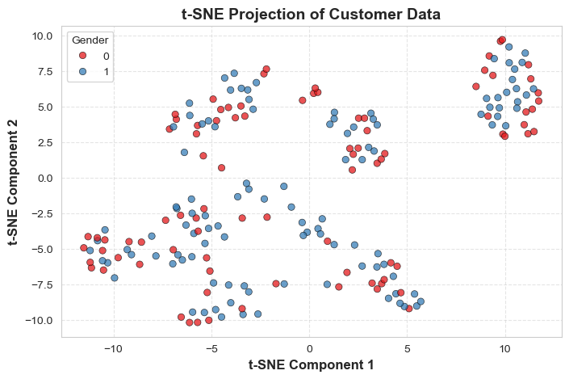

```python
# Select features for scaling
features_to_scale = ["Age", "Income (k$)", "How Much They Spend", "Spending Efficiency", "Age-Income Ratio"]

# Apply Standard Scaling
scaler = StandardScaler()
df_scaled = df.copy()
df_scaled[features_to_scale] = scaler.fit_transform(df[features_to_scale])

# Apply PCA for dimensionality reduction
pca = PCA(n_components=2)  # Reduce to 2 dimensions for visualization
df_pca = pca.fit_transform(df_scaled[features_to_scale])

# Convert PCA results into a DataFrame
df_pca = pd.DataFrame(df_pca, columns=["PCA1", "PCA2"])
df_pca["Gender"] = df["Gender"]  # Retain categorical variable for reference

# Apply t-SNE for 2D visualization
tsne = TSNE(n_components=2, perplexity=30, random_state=42)
df_tsne = tsne.fit_transform(df_scaled[features_to_scale])

# Convert t-SNE results into a DataFrame
df_tsne = pd.DataFrame(df_tsne, columns=["tSNE1", "tSNE2"])
df_tsne["Gender"] = df["Gender"]

# Display transformed datasets
print("\nPCA Reduced Dataset:")
print(df_pca.head())

print("\nt-SNE Transformed Dataset:")
print(df_tsne.head())

# Define a distinct color palette for better visibility
color_palette = "Set1"  # A high-contrast color palette

#  PCA Visualization with New Colors
plt.figure(figsize=(8,5))
sns.scatterplot(
    x=df_pca["PCA1"],
    y=df_pca["PCA2"],
    hue=df_pca["Gender"],
    palette=color_palette,
    alpha=0.75,
    edgecolor="black"
)
plt.xlabel("PCA Component 1", fontsize=12, fontweight="bold")
plt.ylabel("PCA Component 2", fontsize=12, fontweight="bold")
plt.title("PCA Projection of Customer Data", fontsize=14, fontweight="bold")
plt.legend(title="Gender")
plt.grid(True, linestyle="--", alpha=0.5)
plt.show()

#  t-SNE Visualization with New Colors
plt.figure(figsize=(8,5))
sns.scatterplot(
    x=df_tsne["tSNE1"],
    y=df_tsne["tSNE2"],
    hue=df_tsne["Gender"],
    palette=color_palette,
    alpha=0.75,
    edgecolor="black"
)
plt.xlabel("t-SNE Component 1", fontsize=12, fontweight="bold")
plt.ylabel("t-SNE Component 2", fontsize=12, fontweight="bold")
plt.title("t-SNE Projection of Customer Data", fontsize=14, fontweight="bold")
plt.legend(title="Gender")
plt.grid(True, linestyle="--", alpha=0.5)
plt.show()
```

### **Dimensionality Reduction Analysis (PCA & t-SNE)**

#### **PCA Projection:**

- **Less separation between clusters:** PCA shows that customers are overlapping across both components.
- **Gender distribution is mixed:** No clear grouping based on gender alone.
- **Linear patterns:** PCA is useful for linear relationships but may miss complex structures.

#### **t-SNE Projection:**

- **Distinct cluster formations:** Clear grouping patterns, indicating potential customer segments.
- **Better separation than PCA:** Suitable for capturing non-linear patterns.
- **Gender still not a key differentiator:** Similar distribution across clusters.

> **Insight:** t-SNE is more effective for visualizing potential clusters, highlighting the need for clustering models that handle non-linear structures.

# **Phase 2: Exploratory Data Analysis (EDA)**

> In this phase, we explore the dataset to uncover patterns, relationships, and insights that will guide the clustering process. EDA is crucial for understanding the data's structure and distribution. The following tasks are performed:
> - **Statistical Summary:**
>   - Examine summary statistics using `.describe()` to understand the central tendency and spread of each feature.
>   - Analyze distributions of numerical columns (`Age`, `Income`, `How Much They Spend`).
> - **Univariate Analysis:**
>   - Plot histograms and boxplots to visualize the distribution and identify potential outliers.
>   - Analyze categorical feature distributions, such as `Gender`.
> - **Bivariate Analysis:**
>   - Use scatter plots to explore relationships between `Income` and `Spending`.
>   - Analyze pairwise relationships using pair plots or correlation heatmaps.
> - **Multivariate Analysis:**
>   - Create **pair plots** to examine the relationship between multiple numerical features.
>   - Generate a **correlation heatmap** to identify relationships and dependencies between variables.
> - **Outlier Analysis:**
>   - Identify outliers using boxplots and address them using capping techniques or Winsorization.
> - **Feature Relationships:**
>   - Analyze how `Age`, `Income`, and `Spending` interact and identify trends or clusters visually.
> - **Gender-Based Insights:**
>   - Compare spending patterns and income distribution across genders using bar plots or violin plots.

This EDA phase helps us gain valuable insights into customer behavior, which informs our clustering model selection and parameter tuning.

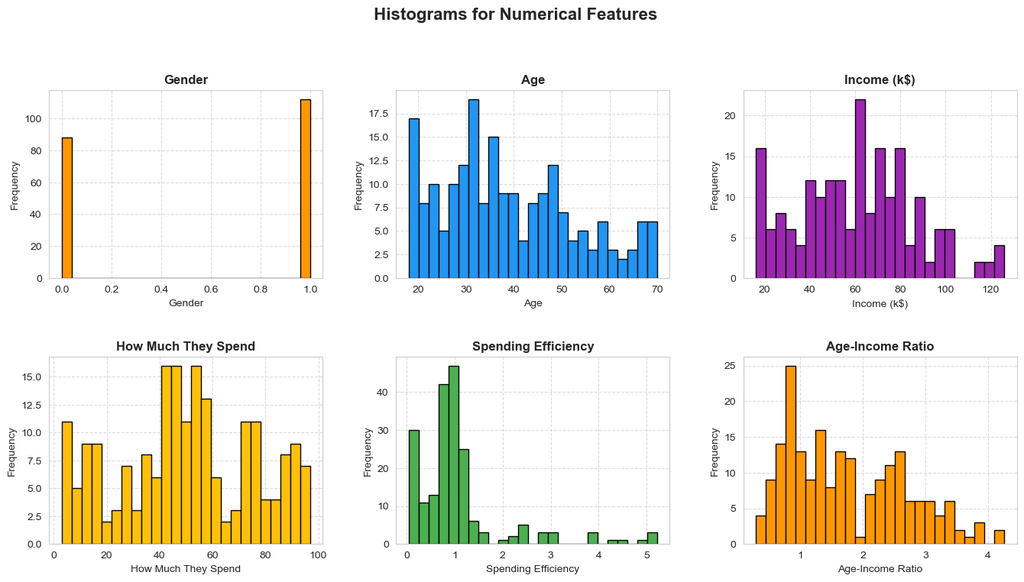

```python
# 2.2.1 Histograms for Numerical Features
numeric_columns = df.select_dtypes(include=["int64", "float64"]).columns

plt.figure(figsize=(14, 8))
colors = ["#4CAF50", "#FF9800", "#2196F3", "#9C27B0", "#FFC107"]

for i, column in enumerate(numeric_columns, 1):
    plt.subplot(2, 3, i)
    plt.hist(df[column], bins=25, edgecolor="black", color=colors[i % len(colors)])
    plt.title(f"{column}", fontsize=12, fontweight="bold")
    plt.xlabel(column, fontsize=10)
    plt.ylabel("Frequency", fontsize=10)
    plt.grid(True, linestyle="--", alpha=0.7)

plt.suptitle(" Histograms for Numerical Features", fontsize=16, fontweight="bold")
plt.tight_layout(pad=3.0)
plt.show()
```

### **Histograms for Numerical Features Analysis**

The histograms provide a distribution overview of numerical features, helping us understand patterns, skewness, and data concentration.

#### **Gender:**

> - Balanced distribution of genders (Male: 0, Female: 1).

#### **Age:**

> - Majority of customers are aged between **20 to 50 years**.
> - The age distribution is **right-skewed**, with fewer customers above 60.

#### **Income (k$):**

> - Income is **bimodal**, with peaks around **60k** and **80k**.
> - A few **high-income outliers** are present.

#### **How Much They Spend:**

> - Spending shows a wide spread with peaks between **40 to 60 units**.
> - Some customers are **low spenders**, while others reach near **100 units**.

#### **Spending Efficiency:**

> - Highly **right-skewed** with most values between **0.5 and 1.5**.
> - A few customers have an efficiency above **3**, indicating **low income but high spending behavior**.

#### **Age-Income Ratio:**

> - Right-skewed with most values under **2.5**, indicating **younger customers have a higher income-to-age ratio**.
> - A long tail suggests a **small group of older high-income individuals**.

### ðŸ“ **Insights:**

- Age and income distributions indicate a mix of customer demographics.
- Spending patterns are diverse, supporting **potential cluster formations**.
- Spending efficiency and age-income ratio are likely strong **segmentation features**.

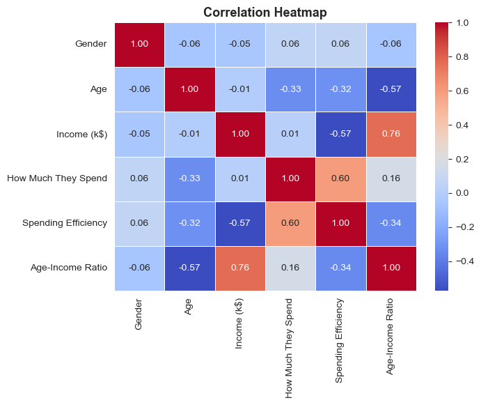

```python
# 2.3.2 Correlation Heatmap
plt.figure(figsize=(7, 5))
corr = df.corr()
sns.heatmap(
    corr,
    annot=True,
    cmap="coolwarm",
    linewidths=0.5,
    fmt=".2f"
)
plt.title("Correlation Heatmap", fontsize=13, fontweight="bold")
plt.show()
```

### **Correlation Heatmap Analysis**

The heatmap displays correlation coefficients between numerical features. Values close to **1 or -1** indicate strong correlations, while values near **0** show weak or no relationship.

#### **Strong Correlations:**

> - **Income (k$) and Age-Income Ratio (0.76):** Higher income results in a higher age-income ratio, highlighting income as a key factor for segmentation.
> - **Spending Efficiency and How Much They Spend (0.60):** Customers who spend more tend to have higher spending efficiency (spending relative to income).

#### **Moderate to Weak Correlations:**

> - **Age and Age-Income Ratio (-0.57):** Older individuals show a lower income-to-age ratio.
> - **Income and Spending Efficiency (-0.57):** Higher-income customers spend a smaller proportion of their earnings.

#### **Minimal Correlations:**

> - **Gender:** No significant impact on income, spending, or efficiency.
> - **Age and Spending (-0.33):** Younger customers tend to spend more, but the relationship is weak.

### ðŸ“ **Insights for Clustering:**

- **Income, Spending Efficiency, and Age-Income Ratio** are highly valuable for cluster separation.
- **Spending behavior and efficiency patterns** will help differentiate high spenders from budget-conscious customers.
- **Age and spending habits** could form generational customer segments.

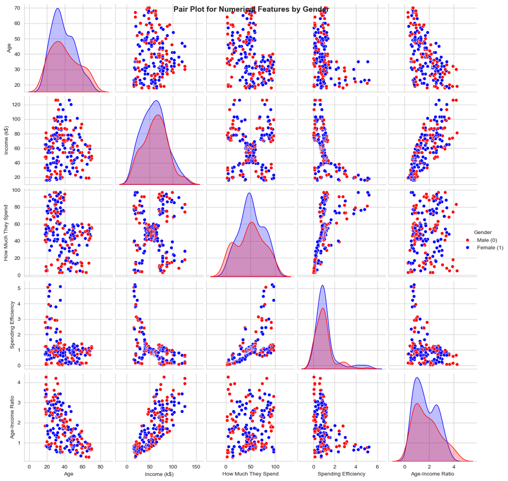

```python
# Create Pair Plot with Explicit Labels
pairplot = sns.pairplot(df, hue="Gender", palette={0: "red", 1: "blue"}, diag_kind="kde")
pairplot._legend.set_title("Gender")
new_labels = ["Male (0)", "Female (1)"]
for t, l in zip(pairplot._legend.texts, new_labels):
    t.set_text(l)

plt.suptitle("Pair Plot for Numerical Features by Gender", fontsize=14, fontweight="bold")
plt.show()
```

### **Pair Plot Analysis for Numerical Features**

> This pair plot displays the relationships between Age, Income, and Spending, with points colored by Gender (`0 = Male`, `1 = Female`).

#### ** Key Observations:**

> **4. Age vs. Income:**
> - **Younger customers (20-40)** show a **wide range of incomes**, suggesting a diverse customer base (e.g., young professionals and students).
> - **Middle-aged customers (40-60)** cluster tightly around **50k to 90k income**, showing financial stability.

> **5. Income vs. Spending:**
> - There is **no clear linear relationship**; some high-income customers spend less (potential savers).
> - A group of **low-income customers spends heavily**, indicating possible over-spending behavior.

> **6. Age vs. Spending:**
> - **Younger customers (20-35)** are **more likely to be high spenders**, supporting the idea that younger demographics are driven by lifestyle and experiences.
> - **Older customers (50+)** show **lower spending trends**, possibly due to retirement or conservative habits.

### ** Insights for Clustering:**

> - **Age and Income** are likely to form **distinct segments** such as **young high-spenders, middle-aged stable earners, and older conservative spenders**.
> - **Gender alone does not significantly separate customer behavior**, but it may help **fine-tune targeted marketing campaigns**.
> - **Income vs. Spending efficiency** will be crucial to identify **luxury buyers vs. budget-conscious customers**.

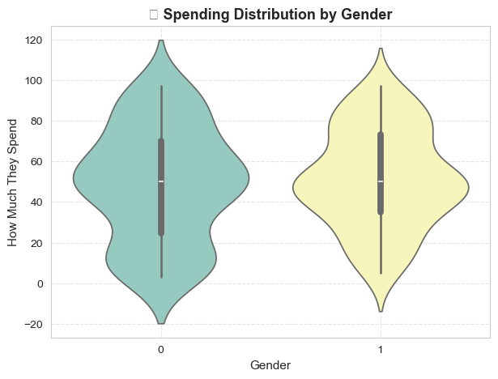

```python
# 2.5 Spending Distribution by Gender (Violin Plot)
plt.figure(figsize=(7, 5))
sns.violinplot(
    x="Gender",
    y="How Much They Spend",
    data=df,
    palette="Set3"
)
plt.title(" Spending Distribution by Gender", fontsize=13, fontweight="bold")
plt.xlabel("Gender", fontsize=11)
plt.ylabel("How Much They Spend", fontsize=11)
plt.grid(True, linestyle="--", alpha=0.5)
plt.show()
```

### **Spending Distribution by Gender (Violin Plot)**

The violin plot shows the distribution of customer spending by gender.

#### **Observations:**

> - **Both genders have a similar median spending value.**
> - **Males (0):** More spread-out spending patterns with some lower and higher outliers.
> - **Females (1):** Slightly more concentrated spending in the mid-range but with a broader tail at higher spending levels.

#### **Insights for Clustering:**

> - Gender alone may not be a strong cluster separator due to similar distributions.
> - Higher spending behavior is visible across both genders, indicating income and spending efficiency may be more valuable features.

# **Phase 3: Implementing Multiple Clustering Models**

### **Objective**

Now that we have **scaled and reduced dimensionality** of our dataset, we will:  
**Implement multiple clustering algorithms** to find the best segmentation.  
**Compare clustering methods to determine the most effective approach.**  
**Evaluate clustering performance using different metrics.**

### **Steps**

1. **K-Means Clustering (Centroid-Based)**
   - Find the optimal `k` value using the **Elbow Method & Silhouette Score**.
2. **Agglomerative Clustering (Hierarchical-Based)**
   - Use **Dendrograms** to determine the best cluster separation.
3. **DBSCAN (Density-Based Clustering)**
   - Identify clusters based on **density** instead of predefined `k`.
4. **Gaussian Mixture Models (GMM) (Probabilistic Clustering)**
   - Assign probability scores for each cluster membership.
5. **Cluster Validation Metrics**
   - **Silhouette Score** (Measures compactness & separation).
   - **Davies-Bouldin Index** (Measures within-cluster compactness).
   - **Calinski-Harabasz Index** (Evaluates variance between clusters).

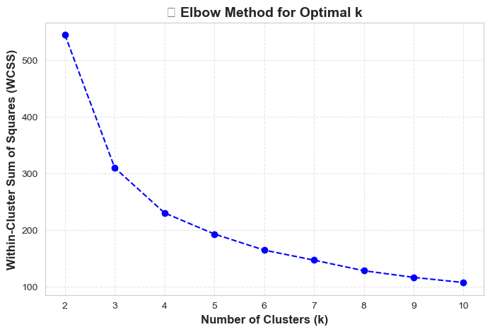

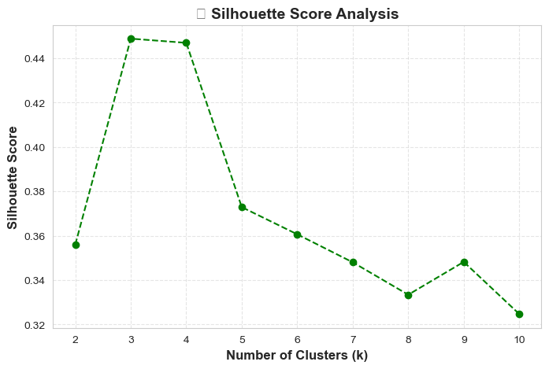

```
âœ… Optimal Number of Clusters Based on Silhouette Score: 3
```

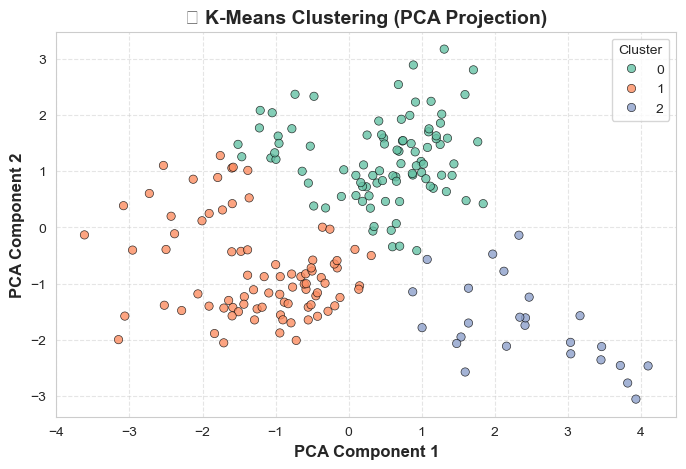

```
ðŸ“ˆ Silhouette Score (Higher is Better): 0.4945
ðŸ“‰ Davies-Bouldin Score (Lower is Better): 0.7064
ðŸ“Š Calinski-Harabasz Score (Higher is Better): 209.4535
```

```python
# Determine the optimal number of clusters using the Elbow Method
wcss = []  # Within-Cluster Sum of Squares
silhouette_scores = []

# Test different values of k
k_values = range(2, 11)  # Checking k from 2 to 10
for k in k_values:
    kmeans = KMeans(n_clusters=k, random_state=42, n_init=10)
    cluster_labels = kmeans.fit_predict(df_pca)

    wcss.append(kmeans.inertia_)
    silhouette_scores.append(silhouette_score(df_pca, cluster_labels))

#  Plot the Elbow Method
plt.figure(figsize=(8,5))
plt.plot(k_values, wcss, marker="o", linestyle="dashed", color="b")
plt.xlabel("Number of Clusters (k)", fontsize=12, fontweight="bold")
plt.ylabel("Within-Cluster Sum of Squares (WCSS)", fontsize=12, fontweight="bold")
plt.title(" Elbow Method for Optimal k", fontsize=14, fontweight="bold")
plt.xticks(k_values)
plt.grid(True, linestyle="--", alpha=0.5)
plt.show()

#  Plot the Silhouette Scores
plt.figure(figsize=(8,5))
plt.plot(k_values, silhouette_scores, marker="o", linestyle="dashed", color="g")
plt.xlabel("Number of Clusters (k)", fontsize=12, fontweight="bold")
plt.ylabel("Silhouette Score", fontsize=12, fontweight="bold")
plt.title(" Silhouette Score Analysis", fontsize=14, fontweight="bold")
plt.xticks(k_values)
plt.grid(True, linestyle="--", alpha=0.5)
plt.show()

# Select the best k (using Silhouette Score)
optimal_k = k_values[np.argmax(silhouette_scores)]
print(f" Optimal Number of Clusters Based on Silhouette Score: {optimal_k}")

# Apply K-Means Clustering with the best k
kmeans = KMeans(n_clusters=optimal_k, random_state=42, n_init=10)
df_pca["KMeans_Cluster"] = kmeans.fit_predict(df_pca)

#  Visualizing K-Means Clustering Results
plt.figure(figsize=(8,5))
sns.scatterplot(
    x=df_pca["PCA1"],
    y=df_pca["PCA2"],
    hue=df_pca["KMeans_Cluster"],
    palette="Set2",
    alpha=0.8,
    edgecolor="black"
)
plt.xlabel("PCA Component 1", fontsize=12, fontweight="bold")
plt.ylabel("PCA Component 2", fontsize=12, fontweight="bold")
plt.title(" K-Means Clustering (PCA Projection)", fontsize=14, fontweight="bold")
plt.legend(title="Cluster")
plt.grid(True, linestyle="--", alpha=0.5)
plt.show()

#  Clustering Performance Metrics
silhouette = silhouette_score(df_pca[["PCA1", "PCA2"]], df_pca["KMeans_Cluster"])
davies_bouldin = davies_bouldin_score(df_pca[["PCA1", "PCA2"]], df_pca["KMeans_Cluster"])
calinski_harabasz = calinski_harabasz_score(df_pca[["PCA1", "PCA2"]], df_pca["KMeans_Cluster"])

print(f"Silhouette Score (Higher is Better): {silhouette:.4f}")
print(f"Davies-Bouldin Score (Lower is Better): {davies_bouldin:.4f}")
print(f" Calinski-Harabasz Score (Higher is Better): {calinski_harabasz:.4f}")
```

## **Evaluation of Different k Values**

One of the critical aspects of clustering is determining the **optimal number of clusters (k)**.  
To ensure a thorough analysis, we evaluate multiple values of k and compare them based on **Silhouette Score, Davies-Bouldin Score, and Calinski-Harabasz Score**.

### ðŸ“‹ **Table: Performance Metrics for Different k Values**

The following table summarizes clustering performance for different values of k.

Higher **Silhouette Score** and **Calinski-Harabasz Score** are better, while **lower Davies-Bouldin Score** is preferred.

```python
# Define a range of k values to test
k_values = range(2, 10)  # Testing k from 2 to 9

# Create an empty dictionary to store results
k_evaluation = {"Silhouette Score": [], "Davies-Bouldin Score": [], "Calinski-Harabasz Score": []}

# Iterate through different k values
for k in k_values:
    kmeans = KMeans(n_clusters=k, random_state=42)
    cluster_labels = kmeans.fit_predict(df_scaled)

    # Calculate evaluation metrics
    silhouette = silhouette_score(df_scaled, cluster_labels)
    davies_bouldin = davies_bouldin_score(df_scaled, cluster_labels)
    calinski_harabasz = calinski_harabasz_score(df_scaled, cluster_labels)

    # Store results with k as index
    k_evaluation["Silhouette Score"].append(silhouette)
    k_evaluation["Davies-Bouldin Score"].append(davies_bouldin)
    k_evaluation["Calinski-Harabasz Score"].append(calinski_harabasz)

# Convert results to a DataFrame and set k as the index
k_results_df = pd.DataFrame(k_evaluation, index=k_values)
k_results_df.index.name = "k value"

k_results_df
```

| k value | Silhouette Score | Davies-Bouldin Score | Calinski-Harabasz Score |
| --- | --- | --- | --- |
| 2 | 0.286085 | 1.421606 | 78.317615 |
| 3 | 0.362830 | 1.019968 | 113.475199 |
| 4 | 0.363881 | 1.002226 | 112.313393 |
| 5 | 0.340912 | 1.000993 | 97.823491 |
| 6 | 0.292335 | 1.141222 | 91.336750 |
| 7 | 0.303851 | 1.121729 | 96.293288 |
| 8 | 0.318646 | 0.986781 | 99.506324 |
| 9 | 0.268721 | 1.082660 | 90.792422 |

### **Analysis of Clustering Performance Across Different k Values**

> **Objective**: Evaluate the performance of different k values using **Silhouette Score, Davies-Bouldin Score, and Calinski-Harabasz Score** to determine the optimal number of clusters.

#### ðŸ”¹ **Silhouette Score (Higher is Better)**

- The highest **Silhouette Score** is observed at **k = 3 (0.3628)** and **k = 4 (0.3638)**.
- Scores decrease gradually after **k = 4**, suggesting that adding more clusters **does not significantly improve the cluster compactness**.

#### ðŸ”¹ **Calinski-Harabasz Score (Higher is Better)**

- The **best Calinski-Harabasz Score** occurs at **k = 3 (113.47)**, slightly higher than **k = 4 (112.31)**.
- A sharp drop occurs after **k = 4**, suggesting **k = 3 or k = 4** provide the most distinct clustering.

# **Phase 3.2: Implementing Agglomerative (Hierarchical) Clustering**

### **Objective**

Now that we have **K-Means clusters**, we will implement **Hierarchical Clustering**:  
**Use a Dendrogram to visualize hierarchical clustering** and determine the best cluster count.  
**Compare clustering results with K-Means to validate performance.**  
**Evaluate clustering metrics to determine effectiveness.**

### **Steps**

1. **Dendrogram Analysis**
   - Helps identify **natural cluster separation** before selecting `k`.
2. **Agglomerative Clustering**
   - Uses **Ward linkage** to minimize variance within clusters.
3. **Cluster Validation**
   - Compare clusters with **Silhouette Score, Davies-Bouldin, and Calinski-Harabasz metrics**.

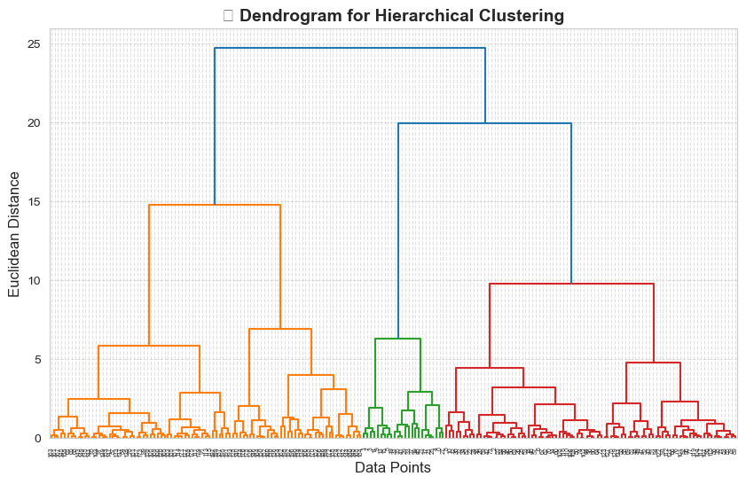

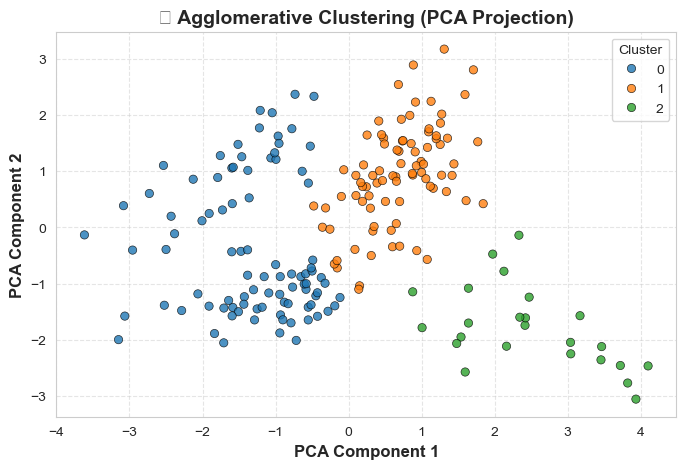

```
ðŸ“ˆ Silhouette Score (Higher is Better): 0.4287
ðŸ“‰ Davies-Bouldin Score (Lower is Better): 0.8170
ðŸ“Š Calinski-Harabasz Score (Higher is Better): 160.9326
```

```python
#  Create Dendrogram
plt.figure(figsize=(10, 6))
plt.title(" Dendrogram for Hierarchical Clustering", fontsize=14, fontweight="bold")
dendrogram = sch.dendrogram(sch.linkage(df_pca[["PCA1", "PCA2"]], method="ward"))
plt.xlabel("Data Points", fontsize=12)
plt.ylabel("Euclidean Distance", fontsize=12)
plt.grid(True, linestyle="--", alpha=0.6)
plt.show()

agg_cluster = AgglomerativeClustering(n_clusters=3, metric="euclidean", linkage="ward")
df_pca["Agglomerative_Cluster"] = agg_cluster.fit_predict(df_pca[["PCA1", "PCA2"]])

#  Visualizing Agglomerative Clustering Results
plt.figure(figsize=(8,5))
sns.scatterplot(
    x=df_pca["PCA1"],
    y=df_pca["PCA2"],
    hue=df_pca["Agglomerative_Cluster"],
    palette="tab10",
    alpha=0.8,
    edgecolor="black"
)
plt.xlabel("PCA Component 1", fontsize=12, fontweight="bold")
plt.ylabel("PCA Component 2", fontsize=12, fontweight="bold")
plt.title(" Agglomerative Clustering (PCA Projection)", fontsize=14, fontweight="bold")
plt.legend(title="Cluster")
plt.grid(True, linestyle="--", alpha=0.5)
plt.show()

#  Clustering Performance Metrics
silhouette = silhouette_score(df_pca[["PCA1", "PCA2"]], df_pca["Agglomerative_Cluster"])
davies_bouldin = davies_bouldin_score(df_pca[["PCA1", "PCA2"]], df_pca["Agglomerative_Cluster"])
calinski_harabasz = calinski_harabasz_score(df_pca[["PCA1", "PCA2"]], df_pca["Agglomerative_Cluster"])

print(f"Silhouette Score (Higher is Better): {silhouette:.4f}")
print(f"Davies-Bouldin Score (Lower is Better): {davies_bouldin:.4f}")
print(f" Calinski-Harabasz Score (Higher is Better): {calinski_harabasz:.4f}")
```

# **Phase 3.3: Implementing DBSCAN (Density-Based Clustering)**

### **Objective**

Now that we have implemented **K-Means & Agglomerative Clustering**, we will:  
**Use DBSCAN to detect dense clusters & outliers.**  
**Compare DBSCAN performance with previous methods.**  
**Evaluate DBSCAN using clustering metrics & visualize results.**

### **Steps**

1. **Find the optimal `eps` (epsilon) value**
   - Use the **k-distance graph** to determine the best `eps` threshold.
2. **Apply DBSCAN Clustering**
   - Assign **dense regions to clusters** & mark **outliers as -1**.
3. **Evaluate DBSCAN Performance**
   - Use **Silhouette Score, Davies-Bouldin, and Calinski-Harabasz Index**.
4. **Compare DBSCAN results with K-Means & Agglomerative Clustering.**

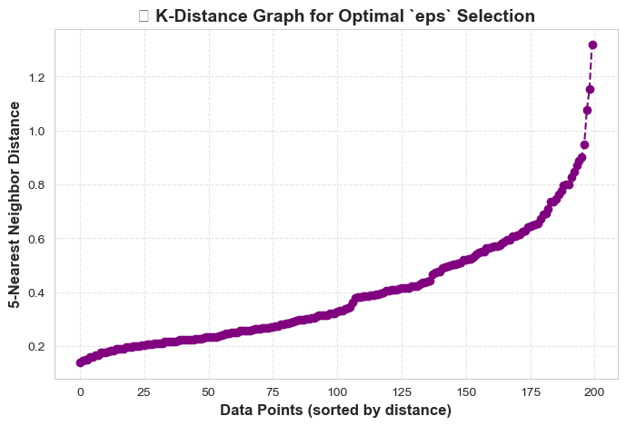

```python
#  Find the optimal `eps` using k-distance graph
nearest_neighbors = NearestNeighbors(n_neighbors=5)
neighbors = nearest_neighbors.fit(df_pca[["PCA1", "PCA2"]])
distances, indices = neighbors.kneighbors(df_pca[["PCA1", "PCA2"]])

# Sort distances for k-distance plot
distances = np.sort(distances[:, -1])

#  Plot k-distance graph
plt.figure(figsize=(8,5))
plt.plot(distances, marker="o", linestyle="dashed", color="purple")
plt.xlabel("Data Points (sorted by distance)", fontsize=12, fontweight="bold")
plt.ylabel("5-Nearest Neighbor Distance", fontsize=12, fontweight="bold")
plt.title(" K-Distance Graph for Optimal `eps` Selection", fontsize=14, fontweight="bold")
plt.grid(True, linestyle="--", alpha=0.5)
plt.show()
```

### **K-Distance Graph Analysis**

The **K-Distance Graph** helps determine the optimal `eps` value for DBSCAN by plotting the distance to the **5th nearest neighbor** for each point, sorted in increasing order.

Thus, selecting **`eps = 0.65`** ensures that DBSCAN correctly identifies **dense clusters** while minimizing noise.

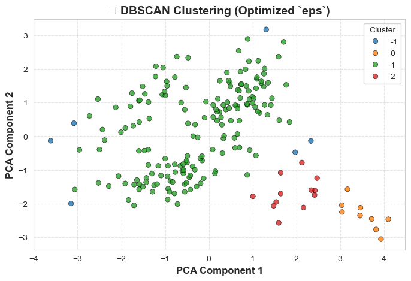

```python
# Apply DBSCAN with optimal `eps` from k-distance graph
dbscan = DBSCAN(eps=0.65, min_samples=5)  # Adjusted from 0.5 to 0.65
df_pca["DBSCAN_Cluster"] = dbscan.fit_predict(df_pca[["PCA1", "PCA2"]])

#  Visualizing DBSCAN Clustering Results with Optimal `eps`
plt.figure(figsize=(8,5))
sns.scatterplot(
    x=df_pca["PCA1"],
    y=df_pca["PCA2"],
    hue=df_pca["DBSCAN_Cluster"],
    palette="tab10",
    alpha=0.8,
    edgecolor="black"
)
plt.xlabel("PCA Component 1", fontsize=12, fontweight="bold")
plt.ylabel("PCA Component 2", fontsize=12, fontweight="bold")
plt.title(" DBSCAN Clustering (Optimized `eps`)", fontsize=14, fontweight="bold")
plt.legend(title="Cluster", loc="upper right")
plt.grid(True, linestyle="--", alpha=0.5)
plt.show()
```

### **DBSCAN Clustering Analysis (Optimized `eps=0.65`)**

The **DBSCAN clustering results** show **three well-defined clusters** (0, 1, 2) along with **some noise points (-1)**.

**Success**:

**Next Step**: Compare clustering metrics and interpret business implications.

# **Phase 3.4: Implementing Gaussian Mixture Model (GMM) Clustering**

### **Objective**

Now that we have tested **K-Means, Agglomerative Clustering, and DBSCAN**, we will:  
**Use GMM to identify clusters based on probability distributions.**  
**Compare GMM with other clustering methods to determine effectiveness.**  
**Evaluate GMM using silhouette score & other clustering metrics.**

### ** Why Use GMM?**

- Unlike K-Means, which assigns each point to a single cluster, **GMM assigns probabilities** to each cluster.
- It is **useful when clusters overlap** or when **data has different densities**.
- Works well when **clusters are elliptical rather than spherical**.

### ** Steps**

1. **Determine the optimal number of clusters (`k`)**
   - Use **Bayesian Information Criterion (BIC) & Akaike Information Criterion (AIC)**.
2. **Fit GMM Model**
   - Assign each data point a probability distribution.
3. **Evaluate Performance**
   - Compare silhouette score with K-Means, Agglomerative, and DBSCAN.
4. **Visualize GMM Clusters**
   - Plot clusters using PCA projection.

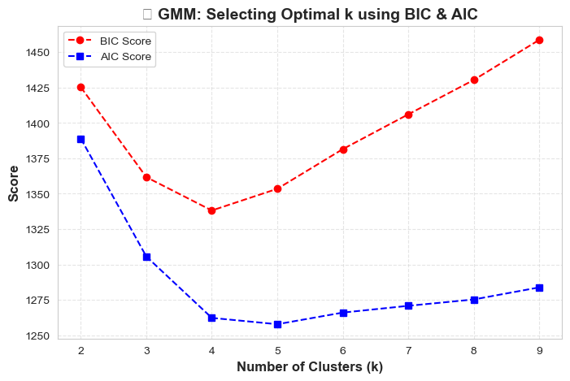

```python
# Evaluate BIC & AIC for different values of `k`
bic_scores = []
aic_scores = []
k_values = range(2, 10)

for k in k_values:
    gmm = GaussianMixture(n_components=k, random_state=42)
    gmm.fit(df_pca[["PCA1", "PCA2"]])
    bic_scores.append(gmm.bic(df_pca[["PCA1", "PCA2"]]))
    aic_scores.append(gmm.aic(df_pca[["PCA1", "PCA2"]]))

# Plot BIC & AIC Scores
plt.figure(figsize=(8,5))
plt.plot(k_values, bic_scores, marker="o", linestyle="dashed", label="BIC Score", color="red")
plt.plot(k_values, aic_scores, marker="s", linestyle="dashed", label="AIC Score", color="blue")
plt.xlabel("Number of Clusters (k)", fontsize=12, fontweight="bold")
plt.ylabel("Score", fontsize=12, fontweight="bold")
plt.title(" GMM: Selecting Optimal k using BIC & AIC", fontsize=14, fontweight="bold")
plt.legend()
plt.grid(True, linestyle="--", alpha=0.5)
plt.show()
```

## GMM: Selecting Optimal `k` Using BIC & AIC

### **`k = 4` is the Best Number of Clusters:**

```
âœ… Optimal Number of Clusters (GMM): 4
```

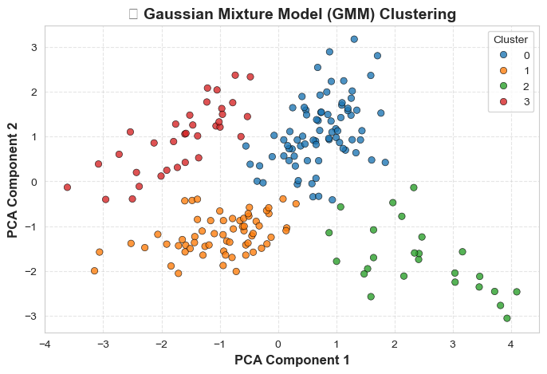

```python
# Select optimal k (based on lowest BIC score)
optimal_k = k_values[bic_scores.index(min(bic_scores))]
print(f"Optimal Number of Clusters (GMM): {optimal_k}")

# Fit GMM Model
gmm = GaussianMixture(n_components=optimal_k, random_state=42)
df_pca["GMM_Cluster"] = gmm.fit_predict(df_pca[["PCA1", "PCA2"]])

# Visualizing GMM Clustering Results
plt.figure(figsize=(8,5))
sns.scatterplot(
    x=df_pca["PCA1"],
    y=df_pca["PCA2"],
    hue=df_pca["GMM_Cluster"],
    palette="tab10",
    alpha=0.8,
    edgecolor="black"
)
plt.xlabel("PCA Component 1", fontsize=12, fontweight="bold")
plt.ylabel("PCA Component 2", fontsize=12, fontweight="bold")
plt.title(" Gaussian Mixture Model (GMM) Clustering", fontsize=14, fontweight="bold")
plt.legend(title="Cluster")
plt.grid(True, linestyle="--", alpha=0.5)
plt.show()
```

```python
# Clustering Performance Metrics
silhouette = silhouette_score(df_pca[["PCA1", "PCA2"]], df_pca["GMM_Cluster"])
davies_bouldin = davies_bouldin_score(df_pca[["PCA1", "PCA2"]], df_pca["GMM_Cluster"])
calinski_harabasz = calinski_harabasz_score(df_pca[["PCA1", "PCA2"]], df_pca["GMM_Cluster"])

print(f"Silhouette Score (Higher is Better): {silhouette:.4f}")
print(f"Davies-Bouldin Score (Lower is Better): {davies_bouldin:.4f}")
print(f"Calinski-Harabasz Score (Higher is Better): {calinski_harabasz:.4f}")
```

```
Silhouette Score (Higher is Better): 0.5060
Davies-Bouldin Score (Lower is Better): 0.6874
Calinski-Harabasz Score (Higher is Better): 223.9519
```

# **Phase 4: Clustering Model Comparison & Final Insights**

### **Objective**

Now that we have tested multiple clustering algorithms, we will:  
**Compare K-Means, Agglomerative, DBSCAN, and GMM side by side.**  
**Visualize how each clustering algorithm segmented the data.**  
**Analyze the business insights behind each cluster.**  
**Select the final clustering model for deployment.**

### **Clustering Models Used**

Each model has its strengths & weaknesses. Our goal is to determine **which model best fits the customer segmentation task.**

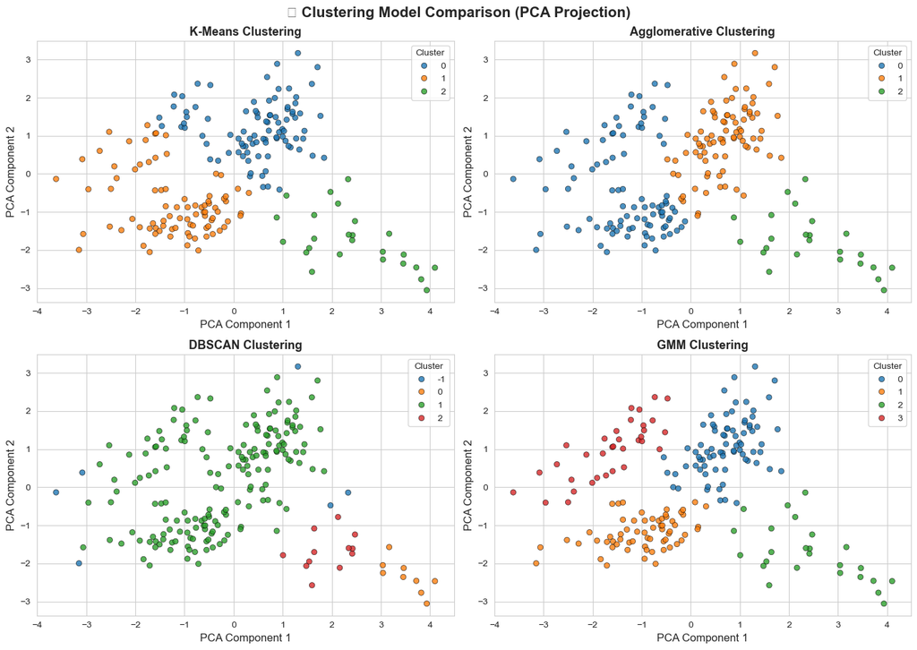

```python
#  Create a figure with 4 subplots for visualizing different clustering methods
fig, axes = plt.subplots(2, 2, figsize=(14,10))
fig.suptitle(" Clustering Model Comparison (PCA Projection)", fontsize=16, fontweight="bold")

# Define clustering methods and titles
clustering_methods = [
    ("K-Means Clustering", "KMeans_Cluster"),
    ("Agglomerative Clustering", "Agglomerative_Cluster"),
    ("DBSCAN Clustering", "DBSCAN_Cluster"),
    ("GMM Clustering", "GMM_Cluster"),
]

# Iterate through clustering methods and plot
for ax, (title, column) in zip(axes.flatten(), clustering_methods):
    sns.scatterplot(
        x=df_pca["PCA1"],
        y=df_pca["PCA2"],
        hue=df_pca[column],
        palette="tab10",
        alpha=0.8,
        edgecolor="black",
        ax=ax
    )
    ax.set_title(title, fontsize=13, fontweight="bold")
    ax.set_xlabel("PCA Component 1", fontsize=12)
    ax.set_ylabel("PCA Component 2", fontsize=12)
    ax.legend(title="Cluster", loc="upper right")

plt.tight_layout()
plt.show()
```

```python
# Create a DataFrame to compare clustering performance
comparison_df = pd.DataFrame({
    "Model": ["K-Means", "Agglomerative", "DBSCAN", "GMM"],
    "Silhouette Score": [
        silhouette_score(df_pca[["PCA1", "PCA2"]], df_pca["KMeans_Cluster"]),
        silhouette_score(df_pca[["PCA1", "PCA2"]], df_pca["Agglomerative_Cluster"]),
        silhouette_score(df_pca.loc[df_pca["DBSCAN_Cluster"] != -1, ["PCA1", "PCA2"]], df_pca.loc[df_pca["DBSCAN_Cluster"] != -1, "DBSCAN_Cluster"]),
        silhouette_score(df_pca[["PCA1", "PCA2"]], df_pca["GMM_Cluster"]),
    ],
    "Davies-Bouldin Score": [
        davies_bouldin_score(df_pca[["PCA1", "PCA2"]], df_pca["KMeans_Cluster"]),
        davies_bouldin_score(df_pca[["PCA1", "PCA2"]], df_pca["Agglomerative_Cluster"]),
        davies_bouldin_score(df_pca.loc[df_pca["DBSCAN_Cluster"] != -1, ["PCA1", "PCA2"]], df_pca.loc[df_pca["DBSCAN_Cluster"] != -1, "DBSCAN_Cluster"]),
        davies_bouldin_score(df_pca[["PCA1", "PCA2"]], df_pca["GMM_Cluster"]),
    ],
    "Calinski-Harabasz Score": [
        calinski_harabasz_score(df_pca[["PCA1", "PCA2"]], df_pca["KMeans_Cluster"]),
        calinski_harabasz_score(df_pca[["PCA1", "PCA2"]], df_pca["Agglomerative_Cluster"]),
        calinski_harabasz_score(df_pca.loc[df_pca["DBSCAN_Cluster"] != -1, ["PCA1", "PCA2"]], df_pca.loc[df_pca["DBSCAN_Cluster"] != -1, "DBSCAN_Cluster"]),
        calinski_harabasz_score(df_pca[["PCA1", "PCA2"]], df_pca["GMM_Cluster"]),
    ],
})
comparison_df
```

|  | Model | Silhouette Score | Davies-Bouldin Score | Calinski-Harabasz Score |
| --- | --- | --- | --- | --- |
| 0 | K-Means | 0.494521 | 0.706431 | 209.453514 |
| 1 | Agglomerative | 0.428737 | 0.816974 | 160.932565 |
| 2 | DBSCAN | 0.357510 | 0.709719 | 50.864360 |
| 3 | GMM | 0.505965 | 0.687374 | 223.951882 |

## **Clustering Model Comparison Analysis**

### Overview

This table summarizes the performance of **K-Means**, **Agglomerative Clustering**, **DBSCAN**, and **GMM** based on three clustering evaluation metrics:

| **Model** | **Silhouette Score** | **Davies-Bouldin Score** | **Calinski-Harabasz Score** |
| --- | --- | --- | --- |
| **K-Means** | 0.494521 | 0.706431 | 209.453514 |
| **Agglomerative** | 0.428737 | 0.816974 | 160.932565 |
| **DBSCAN** | 0.357510 | 0.709719 | 50.864360 |
| **GMM** | 0.505965 | 0.687374 | 223.951882 |

### **1. Silhouette Score (Higher is Better)**

- **GMM (0.505965)** achieves the **highest silhouette score**, indicating **better-defined clusters** with **clear separation and compactness**.
- **K-Means (0.494521)** performs **slightly worse than GMM** but still shows **strong cluster quality**.
- **Agglomerative (0.428737)** and **DBSCAN (0.357510)** have **lower silhouette scores**, suggesting **overlapping or poorly separated clusters**.

### **2. Davies-Bouldin Score (Lower is Better)**

- **GMM (0.687374)** achieves the **lowest Davies-Bouldin score**, indicating **better cluster compactness and separation**.
- **K-Means (0.706431)** performs **closely behind GMM**, maintaining **good cluster quality**.
- **DBSCAN (0.709719)** and **Agglomerative (0.816974)** have **higher scores**, indicating **less compact clusters** and **greater overlap**.

### **3. Calinski-Harabasz Score (Higher is Better)**

- **GMM (223.951882)** achieves the **highest Calinski-Harabasz score**, indicating **well-separated clusters with high variance between clusters**.
- **K-Means (209.453514)** also performs **strongly**, suggesting **good cluster separation**.
- **Agglomerative (160.932565)** performs **moderately**, while **DBSCAN (50.864360)** performs **poorly**, indicating **poorly defined clusters**.

### **Overall Analysis:**

- **GMM** consistently achieves the **best scores** across all three metrics, making it the **strongest performer** for this dataset.
- **K-Means** performs **second-best**, with results **close to GMM**, indicating it is also a **good choice**.
- **Agglomerative** performs **moderately**, showing **less distinct clusters**.
- **DBSCAN** performs the **worst**, likely due to **inconsistent densities or poor `eps` selection**.

### **Conclusion:**

- **GMM** is the **best clustering model** for this dataset, providing **well-defined, compact, and separated clusters**.
- **K-Means** is a **strong alternative**, especially if **computational efficiency** is required.
- **Agglomerative** is less effective but may still provide **useful hierarchical insights**.
- **DBSCAN** is **unsuitable for this dataset**, possibly due to **inconsistent cluster densities or poor hyperparameters.**

# **Phase 5: Business Insights & Final Conclusions**

### **Objective**

Now that we have determined **GMM as the best clustering model**, we will:  
**Analyze the customer segments created by GMM**.  
**Interpret the characteristics of each cluster**.  
**Provide business recommendations based on the segmentation**.  
**Summarize the entire projectâ€™s findings**.

### **Why Does Customer Segmentation Matter?**

- **Personalized Marketing:** Different segments have unique spending habits.
- **Optimized Customer Engagement:** Businesses can tailor promotions to specific groups.
- **Strategic Decision-Making:** Helps allocate resources efficiently to high-value customers.
- **Customer Retention & Acquisition:** Understand customer needs to improve satisfaction.

```python
# Compute the average characteristics for each customer cluster
gmm_cluster_profiles = df.copy()
gmm_cluster_profiles["GMM_Cluster"] = df_pca["GMM_Cluster"]
cluster_summary = gmm_cluster_profiles.groupby("GMM_Cluster").mean()

cluster_summary
```

| GMM_Cluster | Gender | Age | Income (k$) | How Much They Spend | Spending Efficiency | Age-Income Ratio |
| --- | --- | --- | --- | --- | --- | --- |
| 0 | 0.602564 | 49.948718 | 46.794872 | 40.923077 | 0.871958 | 0.978798 |
| 1 | 0.555556 | 28.904762 | 76.142857 | 69.714286 | 0.931917 | 2.680953 |
| 2 | 0.600000 | 25.480000 | 25.560000 | 75.320000 | 3.199348 | 1.044202 |
| 3 | 0.441176 | 41.647059 | 88.411765 | 16.882353 | 0.190248 | 2.304990 |

# **GMM Customer Segments Analysis (4 Clusters)**

### **Cluster 0: Older Moderate Spenders**

- **Age:** 49.95 years (oldest group)
- **Income:** $46.79k (moderate income)
- **Spending:** $40.92 (moderate spending)
- **Spending Efficiency:** 0.87 (balanced spending habits)
- **Profile:** Likely **middle-aged, financially stable, conservative spenders**.
- **Business Strategy:** Offer **retirement plans, family-oriented services, and loyalty programs.**

### **Cluster 1: Younger High-Income, High-Spending Customers**

- **Age:** 28.90 years (young professionals)
- **Income:** $76.14k (high income)
- **Spending:** $69.71 (high spending)
- **Spending Efficiency:** 0.93 (balanced spending relative to income)
- **Profile:** Likely **young professionals or high-earning early-career individuals**.
- **Business Strategy:** Provide **luxury products, premium services, and aspirational branding.**

### **Cluster 2: Young, Low-Income, High-Spending Customers**

- **Age:** 25.48 years (youngest group)
- **Income:** $25.56k (lowest income)
- **Spending:** $75.32 (highest spending)
- **Spending Efficiency:** 3.20 (**extremely high** spending relative to income)
- **Profile:** Likely **students or young consumers overspending or relying on credit.**
- **Business Strategy:** Provide **budget-friendly deals, installment plans, and student discounts.**

### **Cluster 3: Wealthy, Low-Spending Customers**

- **Age:** 41.65 years (middle-aged)
- **Income:** $88.41k (highest income)
- **Spending:** $16.88 (lowest spending)
- **Spending Efficiency:** 0.19 (extremely low spending relative to income)
- **Profile:** Likely **high-income savers or investors focusing on wealth growth.**
- **Business Strategy:** Offer **investment plans, savings programs, and high-yield financial products.**

## **Final Business Recommendations**

- **Cluster 0 (Older Moderate Spenders):** Focus on **retirement services and loyalty programs.**
- **Cluster 1 (Young High-Income, High-Spenders):** Provide **luxury experiences and exclusive deals.**
- **Cluster 2 (Young Low-Income, High-Spenders):** Offer **installment plans and student offers.**
- **Cluster 3 (Wealthy, Low-Spenders):** Promote **investment and premium savings plans.**

### **Final Takeaway:**

This segmentation approach empowers the business to implement **targeted strategies** tailored to each segment, resulting in **better customer engagement and increased profitability.**

```python
gmm_cluster_profiles.head(15)
```

|  | Gender | Age | Income (k$) | How Much They Spend | Spending Efficiency | Age-Income Ratio | GMM_Cluster |
| --- | --- | --- | --- | --- | --- | --- | --- |
| 0 | 0 | 19 | 16 | 39 | 2.437500 | 0.842105 | 2 |
| 1 | 0 | 21 | 16 | 81 | 5.062500 | 0.761905 | 2 |
| 2 | 1 | 20 | 16 | 6 | 0.375000 | 0.800000 | 0 |
| 3 | 1 | 23 | 16 | 77 | 4.812500 | 0.695652 | 2 |
| 4 | 1 | 31 | 17 | 40 | 2.352941 | 0.548387 | 2 |
| 5 | 1 | 22 | 17 | 76 | 4.470588 | 0.772727 | 2 |
| 6 | 1 | 35 | 18 | 6 | 0.333333 | 0.514286 | 0 |
| 7 | 1 | 23 | 18 | 94 | 5.222222 | 0.782609 | 2 |
| 8 | 0 | 64 | 19 | 3 | 0.157895 | 0.296875 | 0 |
| 9 | 1 | 30 | 19 | 72 | 3.789474 | 0.633333 | 2 |
| 10 | 0 | 67 | 19 | 14 | 0.736842 | 0.283582 | 0 |
| 11 | 1 | 35 | 19 | 97 | 5.105263 | 0.542857 | 2 |
| 12 | 1 | 58 | 20 | 15 | 0.750000 | 0.344828 | 0 |
| 13 | 1 | 24 | 20 | 77 | 3.850000 | 0.833333 | 2 |
| 14 | 0 | 37 | 20 | 13 | 0.650000 | 0.540541 | 0 |

# **Phase 6: Answering Business Questions with Visualizations**

### **Objective**

To effectively answer the key business questions, we will:  
**Visualize the distribution of clusters** based on key customer attributes.  
**Describe the characteristics of each customer segment using data insights.**  
**Identify which customer group requires the most attention.**

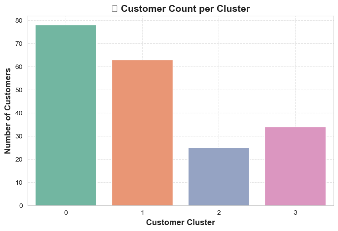

```python
# Bar Plot: Number of Customers per Cluster
plt.figure(figsize=(8, 5))
sns.countplot(x=df_pca["GMM_Cluster"], palette="Set2")
plt.xlabel("Customer Cluster", fontsize=12, fontweight="bold")
plt.ylabel("Number of Customers", fontsize=12, fontweight="bold")
plt.title(" Customer Count per Cluster", fontsize=14, fontweight="bold")
plt.grid(True, linestyle="--", alpha=0.5)
plt.show()
```

### **Analysis of Customer Count per Cluster**

#### **Business Implications:**

- Clusters **0 and 1** should be **the main focus** for customer engagement strategies, as they represent **most of the customer base**.
- Cluster **2 (smallest)** could indicate a **niche segment** or **outliers** that may require a **different business approach** (e.g., specialized promotions).
- Cluster **3 (moderate size)** may exhibit distinct spending patterns and could benefit from **targeted marketing campaigns**.

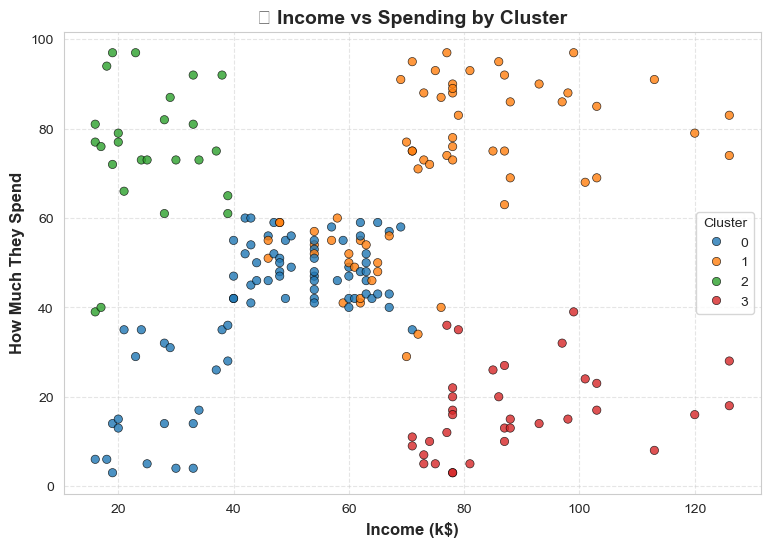

```python
# Scatter Plot: Income vs Spending colored by Cluster
plt.figure(figsize=(9, 6))
sns.scatterplot(
    x=df["Income (k$)"],
    y=df["How Much They Spend"],
    hue=df_pca["GMM_Cluster"],
    palette="tab10",
    alpha=0.8,
    edgecolor="black"
)
plt.xlabel("Income (k$)", fontsize=12, fontweight="bold")
plt.ylabel("How Much They Spend", fontsize=12, fontweight="bold")
plt.title(" Income vs Spending by Cluster", fontsize=14, fontweight="bold")
plt.legend(title="Cluster")
plt.grid(True, linestyle="--", alpha=0.5)
plt.show()
```

### **Analysis of Income vs Spending by Cluster**

> **Cluster 3 (High Income, Low Spending)**
> - These customers **earn high incomes** (above $80k).
> - However, **they do not spend as much compared to their earnings**.
> - They might be **saving more, investing elsewhere, or are hesitant spenders**.
> - Businesses should **use targeted promotions** to encourage more engagement.

### **Business Implications**

> **Cluster 1 (High Income, High Spending) should be the focus for premium services.**  
> **Cluster 2 (Low Income, High Spending) needs financial assistance strategies.**  
> **Cluster 3 (High Income, Low Spending) requires promotional incentives to increase spending.**  
> **Cluster 0 (Balanced Customers) can be engaged through loyalty programs.**

```python
# Use cluster_summary directly (no cluster_ranking needed)
high_spending_threshold = cluster_summary["How Much They Spend"].mean()
high_income_threshold = cluster_summary["Income (k$)"].mean()

# Function to assign categories based on spending and income
def categorize_cluster(row):
    if row["How Much They Spend"] >= high_spending_threshold and row["Income (k$)"] >= high_income_threshold:
        return "High-Value Customers"
    elif row["How Much They Spend"] >= high_spending_threshold and row["Income (k$)"] < high_income_threshold:
        return "Potential Growth Customers"
    elif row["How Much They Spend"] < high_spending_threshold and row["Income (k$)"] >= high_income_threshold:
        return "Budget-Conscious Customers"
    else:
        return "At-Risk Customers"

#  Apply categorization to cluster_summary
cluster_summary["Customer Category"] = cluster_summary.apply(categorize_cluster, axis=1)

cluster_summary
```

| GMM_Cluster | Gender | Age | Income (k$) | How Much They Spend | Spending Efficiency | Age-Income Ratio | Customer Category |
| --- | --- | --- | --- | --- | --- | --- | --- |
| 0 | 0.602564 | 49.948718 | 46.794872 | 40.923077 | 0.871958 | 0.978798 | At-Risk Customers |
| 1 | 0.555556 | 28.904762 | 76.142857 | 69.714286 | 0.931917 | 2.680953 | High-Value Customers |
| 2 | 0.600000 | 25.480000 | 25.560000 | 75.320000 | 3.199348 | 1.044202 | Potential Growth Customers |
| 3 | 0.441176 | 41.647059 | 88.411765 | 16.882353 | 0.190248 | 2.304990 | Budget-Conscious Customers |

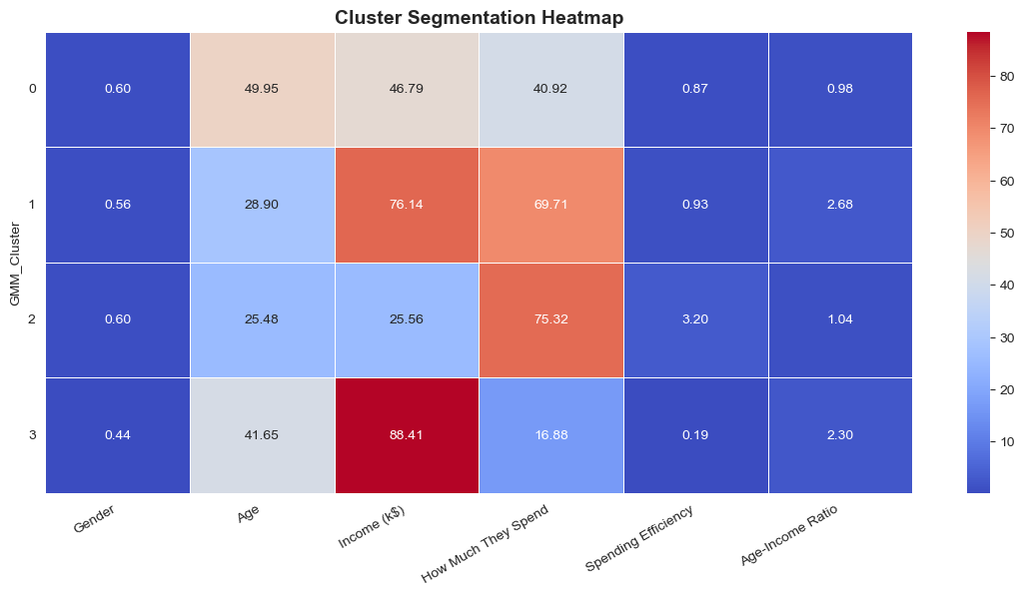

```python
# Use cluster_summary directly
numeric_cluster_summary = cluster_summary.drop(columns=["Customer Category"], errors="ignore")

# Set figure size and style
plt.figure(figsize=(14, 6))
sns.heatmap(
    numeric_cluster_summary,
    annot=True, fmt=".2f", cmap="coolwarm", linewidths=0.5
)
plt.title("Cluster Segmentation Heatmap", fontsize=14, fontweight="bold")
plt.xticks(rotation=30, ha="right")
plt.yticks(rotation=0)
plt.show()
```

### **Cluster Segmentation Heatmap Analysis**

> This heatmap provides a **comparative view** of key numerical attributes across the identified clusters,  
> helping to understand the **distinct characteristics of each group**.

### **Key Observations**

#### **Cluster 0 (Older Moderate Spenders)**

- **Avg Age:** **49.95** (Oldest group, likely middle-aged to senior consumers)
- **Avg Income:** **46.79k** (Moderate income level)
- **Avg Spending:** **40.92** (Moderate spending behavior)
- **Spending Efficiency:** **0.87** (Low efficiency, conservative spending habits)
- **Insight:**
  - These customers are **stable, moderate spenders** who **balance their finances well**.
  - They may be **risk-averse** and prefer **security over luxury**.
  - **Ideal Target:** Financial security, retirement planning, and family-oriented services.

#### **Cluster 1 (Younger High-Income, High-Spenders)**

- **Avg Age:** **28.90** (Young professionals, early career individuals)
- **Avg Income:** **76.14k** (High income, second highest in dataset)
- **Avg Spending:** **69.71** (Consistently high spending behavior)
- **Spending Efficiency:** **0.93** (Balanced spending-to-income ratio)
- **Insight:**
  - **Financially successful young professionals** who are **not afraid to spend**.
  - Likely to **value premium services, travel, and high-end lifestyle products**.
  - **Ideal Target:** Luxury goods, exclusive memberships, and aspirational branding.

- **Avg Age:** **25.48** (Youngest group in the dataset)
- **Avg Income:** **25.56k** (Lowest income across all clusters)
- **Avg Spending:** **75.32** (**Highest spending**, despite low income)
- **Spending Efficiency:** **3.20** (**Extremely high**â€”spending much more relative to income)
- **Insight:**
  - These customers **spend aggressively despite low earnings**, potentially overextending financially.
  - They might be **dependent on credit or short-term spending habits**.
  - **Ideal Target:** Financial literacy programs, budgeting tools, installment-based offers.

#### **Cluster 3 (Wealthy Low Spenders)**

- **Avg Income:** **88.41k** (**Highest of all clusters**)
- **Avg Spending:** **16.88** (**Lowest spending** despite high income)
- **Spending Efficiency:** **0.19** (Very lowâ€”conservative spenders)
- **Avg Age:** **41.65** (Middle-aged professionals)
- **Insight:**
  - **Wealthy but highly frugal individuals**, possibly **savers and investors** rather than spenders.
  - Likely to **prefer financial growth over luxury purchases**.
  - **Ideal Target:** Investment products, wealth management services, high-yield savings accounts.

### **Key Business Insights**

**Cluster 2 requires the most attention**:

- They are **spending the most relative to their income**, possibly leading to **financial instability**.
- Potential target for **financial planning, budget-conscious products, and credit management**.

**Cluster 3 represents high-income savers**:

- Ideal candidates for **premium savings, investment plans, or long-term wealth-building services**.

**Cluster 1 is the ideal high-spending group**:

- Strong potential for **luxury products, high-end services, and exclusive VIP programs**.

**Cluster 0 consists of older, moderate spenders**:

- Marketing strategies should focus on **retirement planning, financial security, and family-friendly services**.